# Automobile Insights - Prediction of Car Prices - Linear Regression

# Importing Packages

```python
# Importing all required packages
import numpy as np
import pandas as pd
import matplotlib.pyplot as plt
import seaborn as sns
%matplotlib inline
from matplotlib.pyplot import xticks

# supress warnings
import warnings
warnings.filterwarnings('ignore')

sns.set(style="darkgrid")
pd.options.display.float_format = '{:.4f}'.format #set it to convert scientific noations such as 4.225108e+11 to 422510842796.00
pd.set_option('display.max_columns', 100) # to display all the columns

np.set_printoptions(suppress=True,formatter={'float_kind':'{:f}'.format})
```

# Step 1: Understanding Data

- Observe Data and Columns
- Number of Entries and Shape of Data
- Numeric and Categorical terms

```python
cars = pd.read_csv('CarPrice_Assignment.csv')
cars.head()
```

|  | car_ID | symboling | CarName | fueltype | aspiration | doornumber | carbody | drivewheel | enginelocation | wheelbase | carlength | carwidth | carheight | curbweight | enginetype | cylindernumber | enginesize | fuelsystem | boreratio | stroke | compressionratio | horsepower | peakrpm | citympg | highwaympg | price |
| --- | --- | --- | --- | --- | --- | --- | --- | --- | --- | --- | --- | --- | --- | --- | --- | --- | --- | --- | --- | --- | --- | --- | --- | --- | --- | --- |
| 0 | 1 | 3 | alfa-romero giulia | gas | std | two | convertible | rwd | front | 88.6000 | 168.8000 | 64.1000 | 48.8000 | 2548 | dohc | four | 130 | mpfi | 3.4700 | 2.6800 | 9.0000 | 111 | 5000 | 21 | 27 | 13495.0000 |
| 1 | 2 | 3 | alfa-romero stelvio | gas | std | two | convertible | rwd | front | 88.6000 | 168.8000 | 64.1000 | 48.8000 | 2548 | dohc | four | 130 | mpfi | 3.4700 | 2.6800 | 9.0000 | 111 | 5000 | 21 | 27 | 16500.0000 |
| 2 | 3 | 1 | alfa-romero Quadrifoglio | gas | std | two | hatchback | rwd | front | 94.5000 | 171.2000 | 65.5000 | 52.4000 | 2823 | ohcv | six | 152 | mpfi | 2.6800 | 3.4700 | 9.0000 | 154 | 5000 | 19 | 26 | 16500.0000 |
| 3 | 4 | 2 | audi 100 ls | gas | std | four | sedan | fwd | front | 99.8000 | 176.6000 | 66.2000 | 54.3000 | 2337 | ohc | four | 109 | mpfi | 3.1900 | 3.4000 | 10.0000 | 102 | 5500 | 24 | 30 | 13950.0000 |
| 4 | 5 | 2 | audi 100ls | gas | std | four | sedan | 4wd | front | 99.4000 | 176.6000 | 66.4000 | 54.3000 | 2824 | ohc | five | 136 | mpfi | 3.1900 | 3.4000 | 8.0000 | 115 | 5500 | 18 | 22 | 17450.0000 |

```python
cars.info()
```

```
<class 'pandas.core.frame.DataFrame'>
RangeIndex: 205 entries, 0 to 204
Data columns (total 26 columns):
 #   Column            Non-Null Count  Dtype
---  ------            --------------  -----
 0   car_ID            205 non-null    int64
 1   symboling         205 non-null    int64
 2   CarName           205 non-null    object
 3   fueltype          205 non-null    object
 4   aspiration        205 non-null    object
 5   doornumber        205 non-null    object
 6   carbody           205 non-null    object
 7   drivewheel        205 non-null    object
 8   enginelocation    205 non-null    object
 9   wheelbase         205 non-null    float64
```

[output cut: 18 more lines]

```python
cars.describe()
```

|  | car_ID | symboling | wheelbase | carlength | carwidth | carheight | curbweight | enginesize | boreratio | stroke | compressionratio | horsepower | peakrpm | citympg | highwaympg | price |
| --- | --- | --- | --- | --- | --- | --- | --- | --- | --- | --- | --- | --- | --- | --- | --- | --- |
| count | 205.0000 | 205.0000 | 205.0000 | 205.0000 | 205.0000 | 205.0000 | 205.0000 | 205.0000 | 205.0000 | 205.0000 | 205.0000 | 205.0000 | 205.0000 | 205.0000 | 205.0000 | 205.0000 |
| mean | 103.0000 | 0.8341 | 98.7566 | 174.0493 | 65.9078 | 53.7249 | 2555.5659 | 126.9073 | 3.3298 | 3.2554 | 10.1425 | 104.1171 | 5125.1220 | 25.2195 | 30.7512 | 13276.7106 |
| std | 59.3226 | 1.2453 | 6.0218 | 12.3373 | 2.1452 | 2.4435 | 520.6802 | 41.6427 | 0.2708 | 0.3136 | 3.9720 | 39.5442 | 476.9856 | 6.5421 | 6.8864 | 7988.8523 |
| min | 1.0000 | -2.0000 | 86.6000 | 141.1000 | 60.3000 | 47.8000 | 1488.0000 | 61.0000 | 2.5400 | 2.0700 | 7.0000 | 48.0000 | 4150.0000 | 13.0000 | 16.0000 | 5118.0000 |
| 25% | 52.0000 | 0.0000 | 94.5000 | 166.3000 | 64.1000 | 52.0000 | 2145.0000 | 97.0000 | 3.1500 | 3.1100 | 8.6000 | 70.0000 | 4800.0000 | 19.0000 | 25.0000 | 7788.0000 |
| 50% | 103.0000 | 1.0000 | 97.0000 | 173.2000 | 65.5000 | 54.1000 | 2414.0000 | 120.0000 | 3.3100 | 3.2900 | 9.0000 | 95.0000 | 5200.0000 | 24.0000 | 30.0000 | 10295.0000 |
| 75% | 154.0000 | 2.0000 | 102.4000 | 183.1000 | 66.9000 | 55.5000 | 2935.0000 | 141.0000 | 3.5800 | 3.4100 | 9.4000 | 116.0000 | 5500.0000 | 30.0000 | 34.0000 | 16503.0000 |
| max | 205.0000 | 3.0000 | 120.9000 | 208.1000 | 72.3000 | 59.8000 | 4066.0000 | 326.0000 | 3.9400 | 4.1700 | 23.0000 | 288.0000 | 6600.0000 | 49.0000 | 54.0000 | 45400.0000 |

```python
cars.shape
```

```
(205, 26)
```

```python
cars.columns
```

```
Index(['car_ID', 'symboling', 'CarName', 'fueltype', 'aspiration',
       'doornumber', 'carbody', 'drivewheel', 'enginelocation', 'wheelbase',
       'carlength', 'carwidth', 'carheight', 'curbweight', 'enginetype',
       'cylindernumber', 'enginesize', 'fuelsystem', 'boreratio', 'stroke',
       'compressionratio', 'horsepower', 'peakrpm', 'citympg', 'highwaympg',
       'price'],
      dtype='object')
```

# Step 2: Data Preparation or Cleaning

- Remove Duplicate Rows (if any)
- Create Derived Columns
- Remove Null Values
- Data Typecasting to numeric or string (if not properly formattted already)

```python
#checking duplicates
sum(cars.duplicated(subset = 'car_ID')) == 0
```

```
True
```

**No duplicate values present in Dataset**

```python
# Checking Null values
cars.isnull().sum()*100/cars.shape[0]
```

```
car_ID             0.0000
symboling          0.0000
CarName            0.0000
fueltype           0.0000
aspiration         0.0000
doornumber         0.0000
carbody            0.0000
drivewheel         0.0000
enginelocation     0.0000
wheelbase          0.0000
carlength          0.0000
carwidth           0.0000
carheight          0.0000
curbweight         0.0000
enginetype         0.0000
cylindernumber     0.0000
enginesize         0.0000
fuelsystem         0.0000
boreratio          0.0000
stroke             0.0000
compressionratio   0.0000
horsepower         0.0000
peakrpm            0.0000
citympg            0.0000
highwaympg         0.0000
price              0.0000
dtype: float64
```

**There are no NULL values in the dataset, hence it is clean.**

```python
#Splitting company name from CarName column
CompanyName = cars['CarName'].apply(lambda x : x.split(' ')[0])
cars.insert(3,"CompanyName",CompanyName)
cars.drop(['CarName'],axis=1,inplace=True)
cars.head()
```

|  | car_ID | symboling | CompanyName | fueltype | aspiration | doornumber | carbody | drivewheel | enginelocation | wheelbase | carlength | carwidth | carheight | curbweight | enginetype | cylindernumber | enginesize | fuelsystem | boreratio | stroke | compressionratio | horsepower | peakrpm | citympg | highwaympg | price |
| --- | --- | --- | --- | --- | --- | --- | --- | --- | --- | --- | --- | --- | --- | --- | --- | --- | --- | --- | --- | --- | --- | --- | --- | --- | --- | --- |
| 0 | 1 | 3 | alfa-romero | gas | std | two | convertible | rwd | front | 88.6000 | 168.8000 | 64.1000 | 48.8000 | 2548 | dohc | four | 130 | mpfi | 3.4700 | 2.6800 | 9.0000 | 111 | 5000 | 21 | 27 | 13495.0000 |
| 1 | 2 | 3 | alfa-romero | gas | std | two | convertible | rwd | front | 88.6000 | 168.8000 | 64.1000 | 48.8000 | 2548 | dohc | four | 130 | mpfi | 3.4700 | 2.6800 | 9.0000 | 111 | 5000 | 21 | 27 | 16500.0000 |
| 2 | 3 | 1 | alfa-romero | gas | std | two | hatchback | rwd | front | 94.5000 | 171.2000 | 65.5000 | 52.4000 | 2823 | ohcv | six | 152 | mpfi | 2.6800 | 3.4700 | 9.0000 | 154 | 5000 | 19 | 26 | 16500.0000 |
| 3 | 4 | 2 | audi | gas | std | four | sedan | fwd | front | 99.8000 | 176.6000 | 66.2000 | 54.3000 | 2337 | ohc | four | 109 | mpfi | 3.1900 | 3.4000 | 10.0000 | 102 | 5500 | 24 | 30 | 13950.0000 |
| 4 | 5 | 2 | audi | gas | std | four | sedan | 4wd | front | 99.4000 | 176.6000 | 66.4000 | 54.3000 | 2824 | ohc | five | 136 | mpfi | 3.1900 | 3.4000 | 8.0000 | 115 | 5500 | 18 | 22 | 17450.0000 |

**Creating Derived Column of Company Name from Car Name**

```python
cars.CompanyName.unique()
```

```
array(['alfa-romero', 'audi', 'bmw', 'chevrolet', 'dodge', 'honda',
       'isuzu', 'jaguar', 'maxda', 'mazda', 'buick', 'mercury',
       'mitsubishi', 'Nissan', 'nissan', 'peugeot', 'plymouth', 'porsche',
       'porcshce', 'renault', 'saab', 'subaru', 'toyota', 'toyouta',
       'vokswagen', 'volkswagen', 'vw', 'volvo'], dtype=object)
```

##### Fixing invalid values

- There seems to be some spelling error in the CompanyName column.
  - `maxda` = `mazda`
  - `Nissan` = `nissan`
  - `porsche` = `porcshce`
  - `toyota` = `toyouta`
  - `vokswagen` = `volkswagen` = `vw`

```python
cars.CompanyName = cars.CompanyName.str.lower()

def replace_name(a,b):
    cars.CompanyName.replace(a,b,inplace=True)

replace_name('maxda','mazda')
replace_name('porcshce','porsche')
replace_name('toyouta','toyota')
replace_name('vokswagen','volkswagen')
replace_name('vw','volkswagen')

cars.CompanyName.unique()
```

```
array(['alfa-romero', 'audi', 'bmw', 'chevrolet', 'dodge', 'honda',
       'isuzu', 'jaguar', 'mazda', 'buick', 'mercury', 'mitsubishi',
       'nissan', 'peugeot', 'plymouth', 'porsche', 'renault', 'saab',
       'subaru', 'toyota', 'volkswagen', 'volvo'], dtype=object)
```

**Now CompanyName spelling error is fixed**

# Step 3: Data Analysis (EDA)

- Perform Univariate Analysis
- Perform Bivariate/Multivariate Analysis
- Understand Vairable that have high correlation with Price and which are also significant

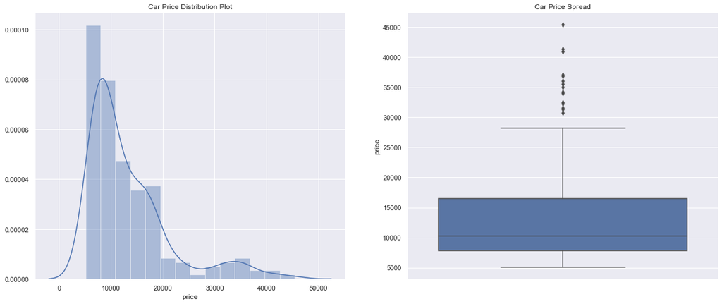

```python
plt.figure(figsize=(20,8))

plt.subplot(1,2,1)
plt.title('Car Price Distribution Plot')
sns.distplot(cars.price)

plt.subplot(1,2,2)
plt.title('Car Price Spread')
sns.boxplot(y=cars.price)

plt.show()
```

```python
print(cars.price.describe(percentiles = [0.25,0.50,0.75,0.85,0.90,1]))
```

```
count     205.0000
mean    13276.7106
std      7988.8523
min      5118.0000
25%      7788.0000
50%     10295.0000
75%     16503.0000
85%     18500.0000
90%     22563.0000
100%    45400.0000
max     45400.0000
Name: price, dtype: float64
```

#### Inference :

1. The plot seemed to be right-skewed, meaning that the most prices in the dataset are low(Below 15,000).
2. There is a significant difference between the mean and the median of the price distribution.
3. The data points are far spread out from the mean, which indicates a high variance in the car prices.(85% of the prices are below 18,500, whereas the remaining 15% are between 18,500 and 45,400.)

#### Visualising Categorical Data

```
- CompanyName
- Symboling
- fueltype
- enginetype
- carbody
- doornumber
- enginelocation
- fuelsystem
- cylindernumber
- aspiration
- drivewheel
```

### Attribute - Car Company, Fuel Type, Car Type

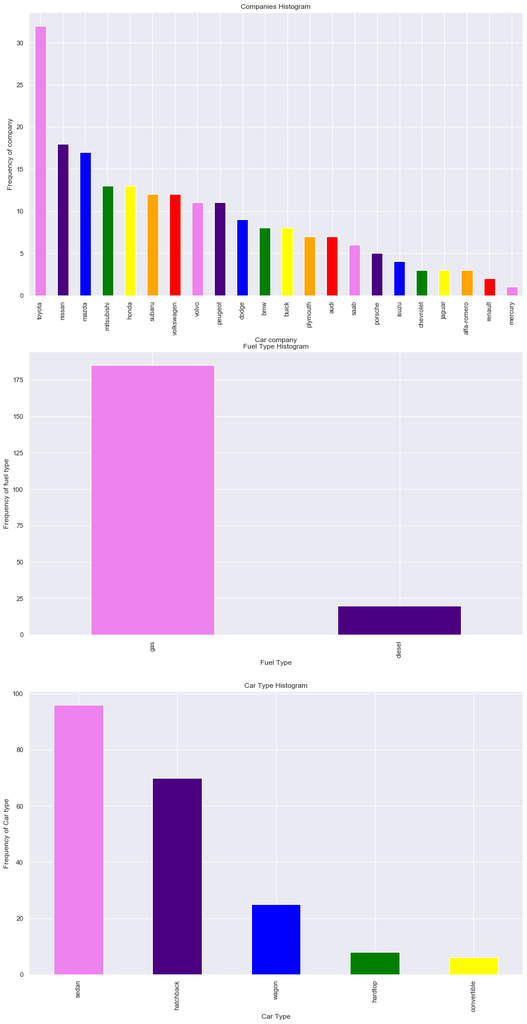

```python
plt.figure(figsize=(15,30))

colors = ['violet', 'indigo', 'blue', 'green', 'yellow', 'orange', 'red']

plt.subplot(3,1,1)
plt1 = cars.CompanyName.value_counts().plot.bar(color=colors)
plt.title('Companies Histogram')
plt1.set(xlabel = 'Car company', ylabel='Frequency of company')

plt.subplot(3,1,2)
plt1 = cars.fueltype.value_counts().plot.bar(color=colors)
plt.title('Fuel Type Histogram')
plt1.set(xlabel = 'Fuel Type', ylabel='Frequency of fuel type')

plt.subplot(3,1,3)
plt1 = cars.carbody.value_counts().plot.bar(color=colors)
plt.title('Car Type Histogram')
plt1.set(xlabel = 'Car Type', ylabel='Frequency of Car type')

plt.show()
```

#### Inference :

1. `Toyota` seemed to be favored car company.
2. Number of `gas` fueled cars are more than `diesel`.
3. `sedan` is the top car type prefered.

### Attribute - Symboling

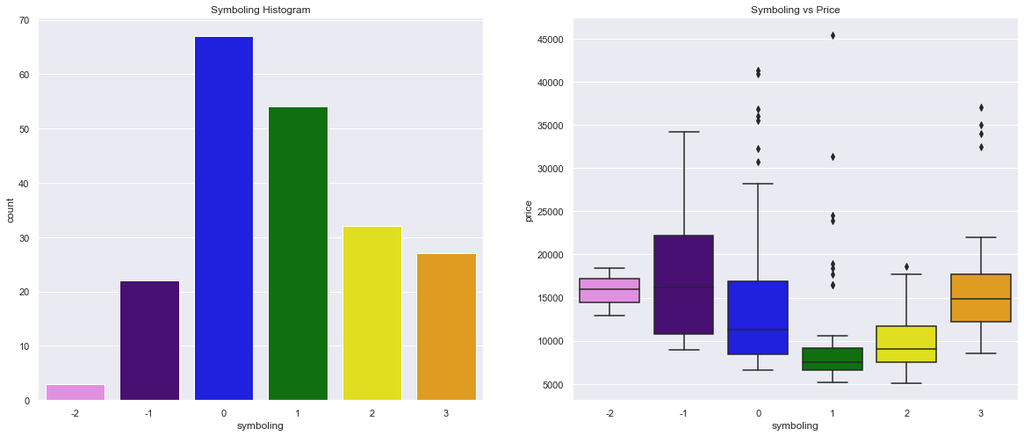

```python
plt.figure(figsize=(20,8))
sns.set_palette(sns.color_palette(colors))

plt.subplot(1,2,1)
plt.title('Symboling Histogram')
sns.countplot(cars.symboling)

plt.subplot(1,2,2)
plt.title('Symboling vs Price')
sns.boxplot(x=cars.symboling, y=cars.price)

plt.show()
```

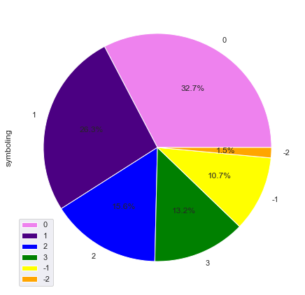

```python
df_sym = pd.DataFrame(cars['symboling'].value_counts())
# df_sym.index.values.sort()
df_sym.plot.pie(subplots=True,labels = df_sym.index.values, autopct='%1.1f%%', figsize = (15,7.5), colors=colors)
# Unsquish the pie.
plt.gca().set_aspect('equal')
plt.show()
```

### Inference :

1. It seems that the symboling with `0` and `1` values have high number of rows (i.e. They are most sold.)
2. The cars with `-1` symboling seems to be high priced (as it makes sense too, insurance risk rating -1 is quite good). But it seems that symboling with `3` value has the price range similar to `-2` value. There is a dip in price at symboling `1`.

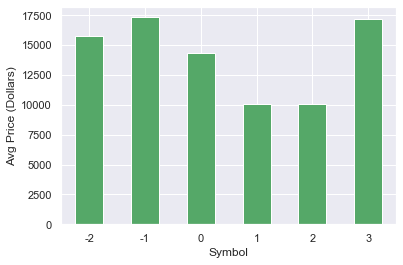

```python
plt1 = cars[['symboling','price']].groupby("symboling").mean().plot.bar(legend = False, color=['g'])
plt1.set_xlabel("Symbol")
plt1.set_ylabel("Avg Price (Dollars)")
xticks(rotation = 0)
plt.show()
```

### Inference

More than 50% of cars are with symbol 0 or 1. Average price of car is lower for 0,1 & 2 symbol category.

### Attribute - Engine Type

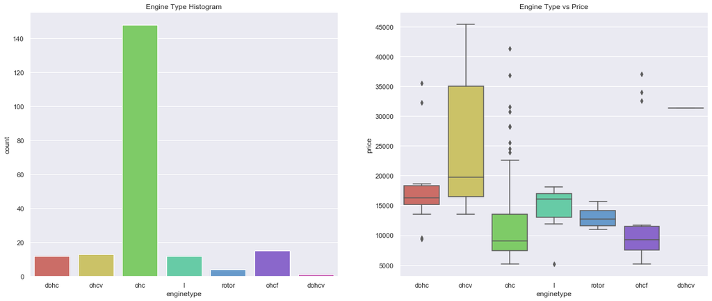

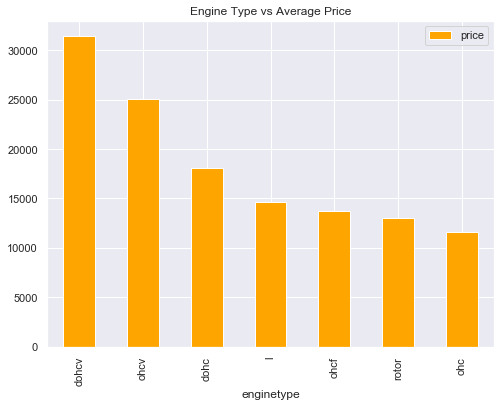

```python
plt.figure(figsize=(20,8))

plt.subplot(1,2,1)
plt.title('Engine Type Histogram')
sns.countplot(cars.enginetype, palette=("hls"))

plt.subplot(1,2,2)
plt.title('Engine Type vs Price')
sns.boxplot(x=cars.enginetype, y=cars.price, palette=("hls"))

plt.show()

df = pd.DataFrame(cars.groupby(['enginetype'])['price'].mean().sort_values(ascending = False))
df.plot.bar(figsize=(8,6), color=['orange'])
plt.title('Engine Type vs Average Price')
plt.show()
```

### Inference :

1. `ohc` Engine type seems to be most favored type.
2. `ohcv` has the highest price range (While `dohcv` has only one row), `ohc` and `ohcf` have the low price range.

### Attribute - Bivariate Analysis with (Company Name, Fuel Type, Car type) with Prices

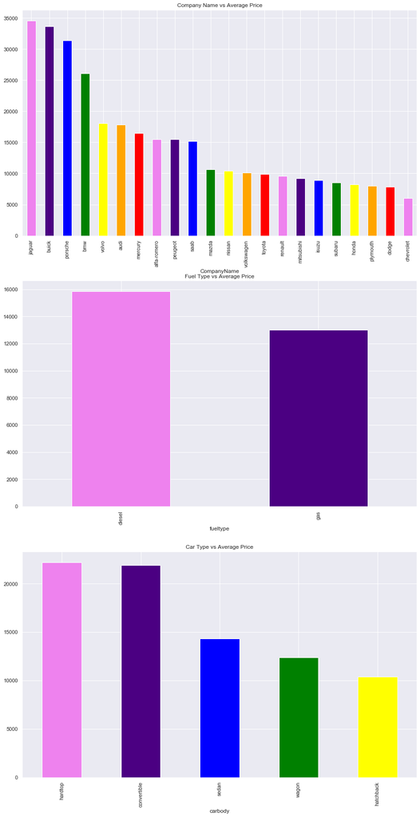

```python
plt.figure(figsize=(15,30))
colors = ['violet', 'indigo', 'blue', 'green', 'yellow', 'orange', 'red']

plt.subplot(3,1,1)
plt1 = cars.groupby(['CompanyName'])['price'].mean().sort_values(ascending = False).plot.bar(color=colors)
plt.title('Company Name vs Average Price')

plt.subplot(3,1,2)
plt1 = cars.groupby(['fueltype'])['price'].mean().sort_values(ascending = False).plot.bar(color=colors)
plt.title('Fuel Type vs Average Price')

plt.subplot(3,1,3)
plt1 = cars.groupby(['carbody'])['price'].mean().sort_values(ascending = False).plot.bar(color=colors)
plt.title('Car Type vs Average Price')

plt.show()
```

### Inference :

1. `Jaguar` and `Buick` seem to have highest average price.
2. `diesel` has higher average price than gas.
3. `hardtop` and `convertible` have higher average price.

### Attribute Univariate and Bivariate Analysis - Door number & Aspiration

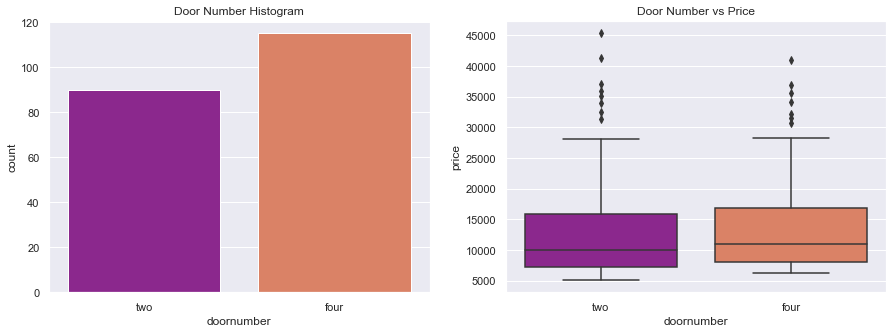

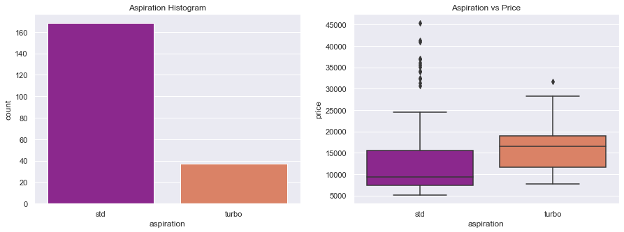

```python
plt.figure(figsize=(15,5))

plt.subplot(1,2,1)
plt.title('Door Number Histogram')
sns.countplot(cars.doornumber, palette=("plasma"))

plt.subplot(1,2,2)
plt.title('Door Number vs Price')
sns.boxplot(x=cars.doornumber, y=cars.price, palette=("plasma"))

plt.show()

plt.figure(figsize=(15,5))

plt.subplot(1,2,1)
plt.title('Aspiration Histogram')
sns.countplot(cars.aspiration, palette=("plasma"))

plt.subplot(1,2,2)
plt.title('Aspiration vs Price')
sns.boxplot(x=cars.aspiration, y=cars.price, palette=("plasma"))

plt.show()
```

### Inference :

1. `doornumber` variable is not affacting the price much. There is no sugnificant difference between the categories in it.
2. It seems aspiration with `turbo` have higher price range than the `std`(though it has some high values outside the whiskers.)

### Attribute Univariate and Bivariate Analysis - Engine Location, Cylinder Number, Fuel System, Drive Wheel

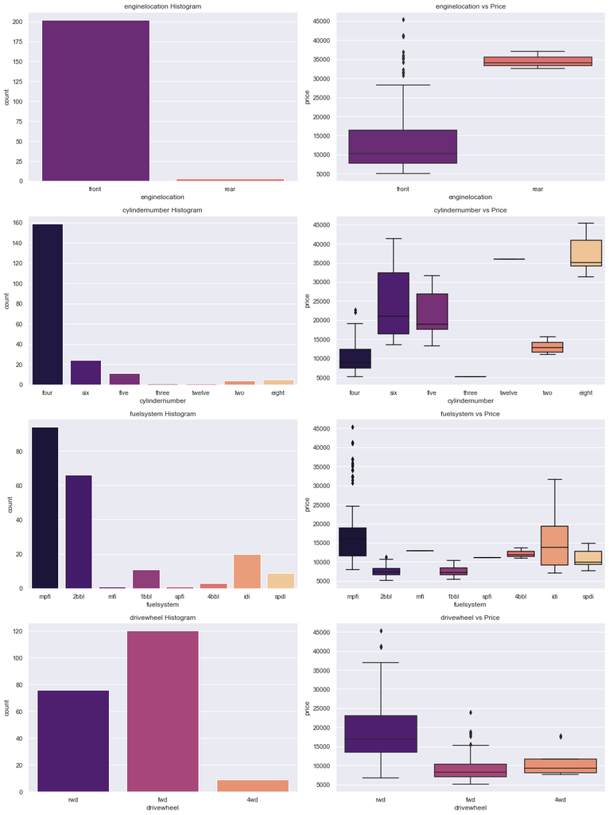

```python
def plot_count(x,fig):
    plt.subplot(4,2,fig)
    plt.title(x+' Histogram')
    sns.countplot(cars[x],palette=("magma"))
    plt.subplot(4,2,(fig+1))
    plt.title(x+' vs Price')
    sns.boxplot(x=cars[x], y=cars.price, palette=("magma"))

plt.figure(figsize=(15,20))

plot_count('enginelocation', 1)
plot_count('cylindernumber', 3)
plot_count('fuelsystem', 5)
plot_count('drivewheel', 7)

plt.tight_layout()
```

### Inference :

1. Very few datapoints for `enginelocation` categories to make an inference.
2. Most common number of cylinders are `four`, `six` and `five`. Though `eight` cylinders have the highest price range.
3. `mpfi` and `2bbl` are most common type of fuel systems. `mpfi` and `idi` having the highest price range. But there are few data for other categories to derive any meaningful inference
4. A very significant difference in drivewheel category. Most high ranged cars seeme to prefer `rwd` drivewheel.

### Attribute Univariate and Bivariate Analysis - Carlength, Carwidth, Carheight, Carweight

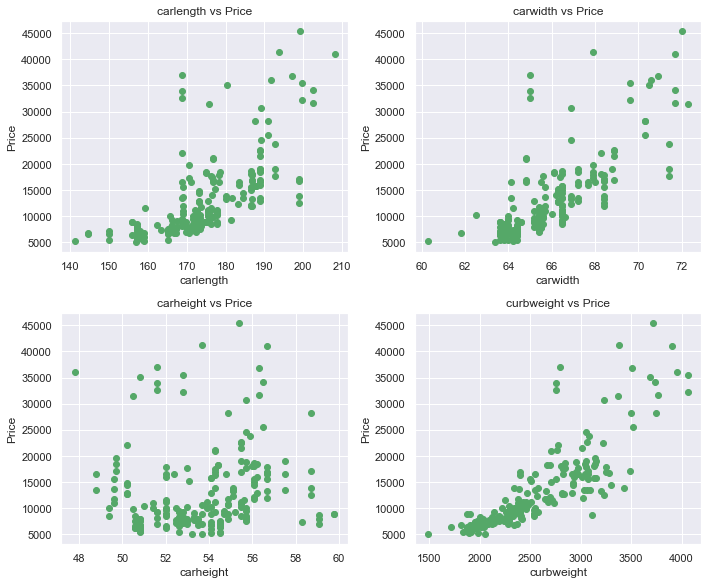

```python
def scatter(x,fig):
    plt.subplot(5,2,fig)
    plt.scatter(cars[x],cars['price'], color=['g'])
    plt.title(x+' vs Price')
    plt.ylabel('Price')
    plt.xlabel(x)

plt.figure(figsize=(10,20))

scatter('carlength', 1)
scatter('carwidth', 2)
scatter('carheight', 3)
scatter('curbweight', 4)

plt.tight_layout()
```

### Inference :

1. `carwidth`, `carlength` and `curbweight` seems to have a poitive correlation with `price`.
2. `carheight` doesn't show any significant trend with price.

### Attribute Univariate and Bivariate Analysis

- Engine Size
- Compression Ratio
- Wheel Base
- Stroke
- Boreratio
- Horsepower
- peakrpm
- citympg
- highwaympg

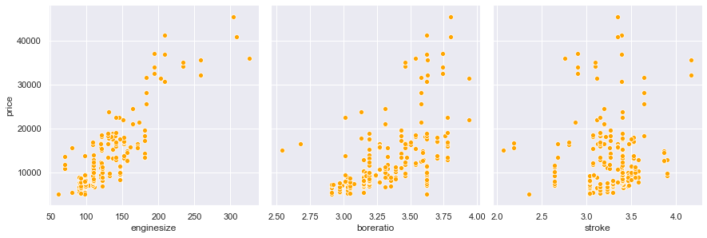

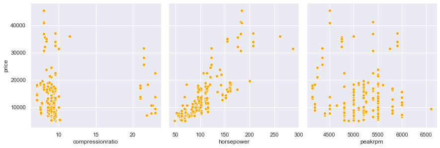

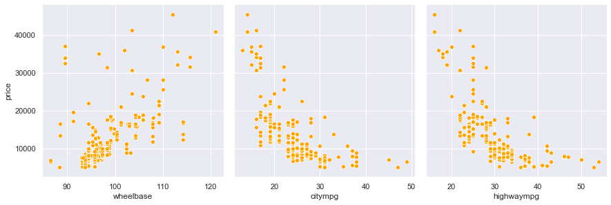

```python
sns.set_palette(sns.color_palette(['orange']))
def pp(x,y,z):
    sns.pairplot(cars, x_vars=[x,y,z], y_vars='price',size=4, aspect=1, kind='scatter')
    plt.show()

pp('enginesize', 'boreratio', 'stroke')
pp('compressionratio', 'horsepower', 'peakrpm')
pp('wheelbase', 'citympg', 'highwaympg')
```

### Inference :

1. `enginesize`, `boreratio`, `horsepower`, `wheelbase` - seem to have a significant positive correlation with price.
2. `citympg`, `highwaympg` - seem to have a significant negative correlation with price.

```python
np.corrcoef(cars['carlength'], cars['carwidth'])[0, 1]
```

```
0.841118268481846
```

- Carlength and Carwidth are highly Correlated

### Deriving New Features

```python
#Fuel economy
cars['fueleconomy'] = (0.55 * cars['citympg']) + (0.45 * cars['highwaympg'])
```

```python
#Binning the Car Companies based on avg prices of each Company.
cars['price'] = cars['price'].astype('int')
temp = cars.copy()
table = temp.groupby(['CompanyName'])['price'].mean()
temp = temp.merge(table.reset_index(), how='left',on='CompanyName')
bins = [0,10000,20000,40000]
cars_bin=['Budget','Medium','Highend']
cars['carsrange'] = pd.cut(temp['price_y'],bins,right=False,labels=cars_bin)
cars.head()
```

|  | car_ID | symboling | CompanyName | fueltype | aspiration | doornumber | carbody | drivewheel | enginelocation | wheelbase | carlength | carwidth | carheight | curbweight | enginetype | cylindernumber | enginesize | fuelsystem | boreratio | stroke | compressionratio | horsepower | peakrpm | citympg | highwaympg | price | fueleconomy | carsrange |
| --- | --- | --- | --- | --- | --- | --- | --- | --- | --- | --- | --- | --- | --- | --- | --- | --- | --- | --- | --- | --- | --- | --- | --- | --- | --- | --- | --- | --- |
| 0 | 1 | 3 | alfa-romero | gas | std | two | convertible | rwd | front | 88.6000 | 168.8000 | 64.1000 | 48.8000 | 2548 | dohc | four | 130 | mpfi | 3.4700 | 2.6800 | 9.0000 | 111 | 5000 | 21 | 27 | 13495 | 23.7000 | Medium |
| 1 | 2 | 3 | alfa-romero | gas | std | two | convertible | rwd | front | 88.6000 | 168.8000 | 64.1000 | 48.8000 | 2548 | dohc | four | 130 | mpfi | 3.4700 | 2.6800 | 9.0000 | 111 | 5000 | 21 | 27 | 16500 | 23.7000 | Medium |
| 2 | 3 | 1 | alfa-romero | gas | std | two | hatchback | rwd | front | 94.5000 | 171.2000 | 65.5000 | 52.4000 | 2823 | ohcv | six | 152 | mpfi | 2.6800 | 3.4700 | 9.0000 | 154 | 5000 | 19 | 26 | 16500 | 22.1500 | Medium |
| 3 | 4 | 2 | audi | gas | std | four | sedan | fwd | front | 99.8000 | 176.6000 | 66.2000 | 54.3000 | 2337 | ohc | four | 109 | mpfi | 3.1900 | 3.4000 | 10.0000 | 102 | 5500 | 24 | 30 | 13950 | 26.7000 | Medium |
| 4 | 5 | 2 | audi | gas | std | four | sedan | 4wd | front | 99.4000 | 176.6000 | 66.4000 | 54.3000 | 2824 | ohc | five | 136 | mpfi | 3.1900 | 3.4000 | 8.0000 | 115 | 5500 | 18 | 22 | 17450 | 19.8000 | Medium |

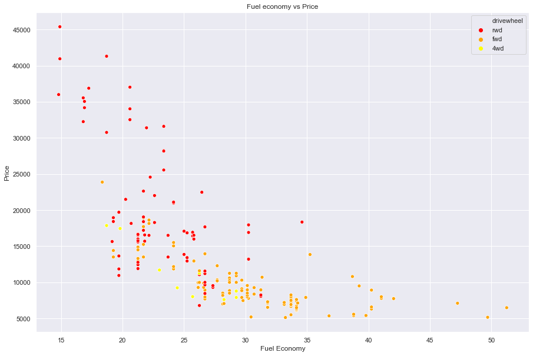

```python
plt.figure(figsize=(15,10))
sns.set_palette(sns.color_palette(['red','orange','yellow']))
plt.title('Fuel economy vs Price')
sns.scatterplot(x=cars['fueleconomy'],y=cars['price'],hue=cars['drivewheel'])
plt.xlabel('Fuel Economy')
plt.ylabel('Price')

plt.show()
plt.tight_layout()
```

### Inference :

1. `fueleconomy` has an obvios `negative correlation` with price and is significant.

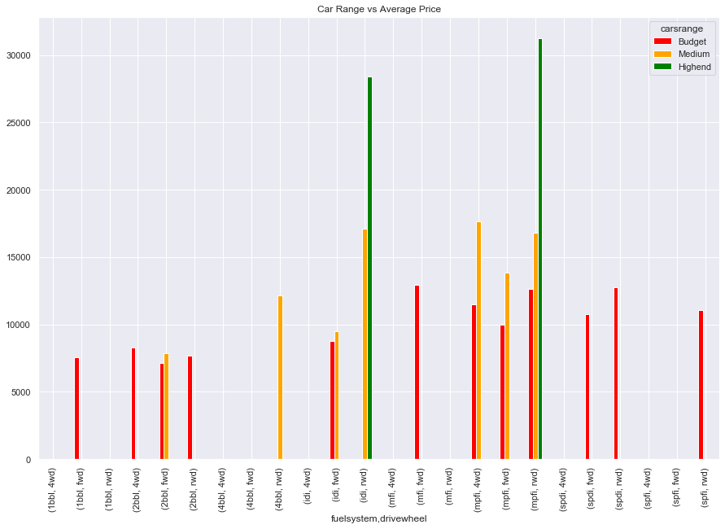

```python
df = cars.groupby(['fuelsystem','drivewheel','carsrange'])['price'].mean().unstack(fill_value=0).plot.bar(figsize=(15, 10),
                color=['red','orange','green'])
plt.title('Car Range vs Average Price')
plt.show()
plt.tight_layout()
```

### Inference :

1. High ranged cars prefer `rwd` drivewheel with `idi` or `mpfi` fuelsystem.

### List of significant variables after Visual analysis :

- Car Range
- Engine Type
- Fuel type
- Car Body
- Aspiration
- Cylinder Number
- Drivewheel
- Curbweight
- Car Length
- Car width
- Engine Size
- Boreratio
- Horse Power
- Wheel base
- Fuel Economy
- brand Category

### Data Slicing and Taking only relevant variables

```python
cars_lr = cars[['price', 'fueltype', 'aspiration','carbody', 'drivewheel','wheelbase',
                  'curbweight', 'enginetype', 'cylindernumber', 'enginesize', 'boreratio','horsepower',
                    'fueleconomy', 'carlength','carwidth', 'carsrange']]
cars_lr.head()
```

|  | price | fueltype | aspiration | carbody | drivewheel | wheelbase | curbweight | enginetype | cylindernumber | enginesize | boreratio | horsepower | fueleconomy | carlength | carwidth | carsrange |
| --- | --- | --- | --- | --- | --- | --- | --- | --- | --- | --- | --- | --- | --- | --- | --- | --- |
| 0 | 13495 | gas | std | convertible | rwd | 88.6000 | 2548 | dohc | four | 130 | 3.4700 | 111 | 23.7000 | 168.8000 | 64.1000 | Medium |
| 1 | 16500 | gas | std | convertible | rwd | 88.6000 | 2548 | dohc | four | 130 | 3.4700 | 111 | 23.7000 | 168.8000 | 64.1000 | Medium |
| 2 | 16500 | gas | std | hatchback | rwd | 94.5000 | 2823 | ohcv | six | 152 | 2.6800 | 154 | 22.1500 | 171.2000 | 65.5000 | Medium |
| 3 | 13950 | gas | std | sedan | fwd | 99.8000 | 2337 | ohc | four | 109 | 3.1900 | 102 | 26.7000 | 176.6000 | 66.2000 | Medium |
| 4 | 17450 | gas | std | sedan | 4wd | 99.4000 | 2824 | ohc | five | 136 | 3.1900 | 115 | 19.8000 | 176.6000 | 66.4000 | Medium |

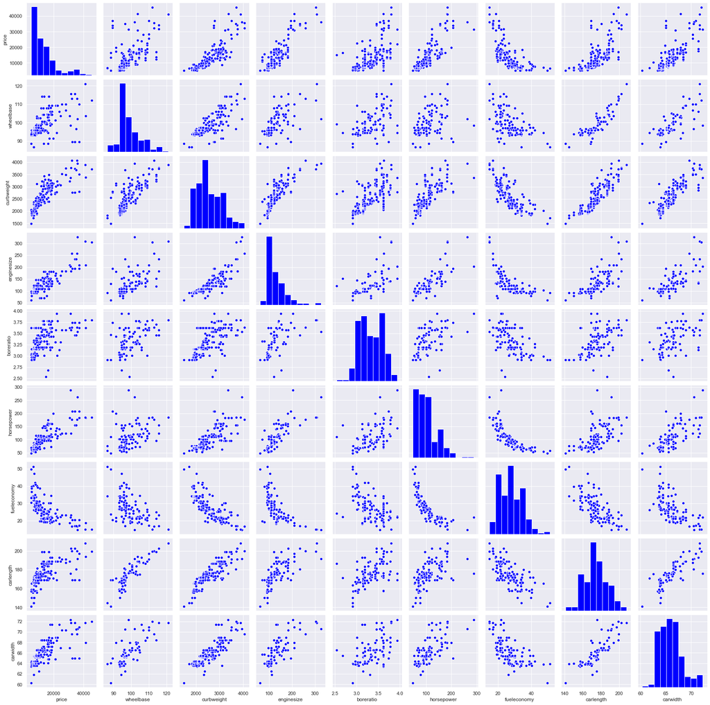

```python
sns.set_palette(sns.color_palette(['blue']))
sns.pairplot(cars_lr)
plt.show()
```

## Dummy Variables

```python
# Defining the map function
def dummies(x,df):
    temp = pd.get_dummies(df[x], drop_first = True)
    df = pd.concat([df, temp], axis = 1)
    df.drop([x], axis = 1, inplace = True)
    return df

# Applying the function to the cars_lr
cars_lr = dummies('fueltype',cars_lr)
cars_lr = dummies('aspiration',cars_lr)
cars_lr = dummies('carbody',cars_lr)
cars_lr = dummies('drivewheel',cars_lr)
cars_lr = dummies('enginetype',cars_lr)
cars_lr = dummies('cylindernumber',cars_lr)
cars_lr = dummies('carsrange',cars_lr)
```

```python
cars_lr.head()
```

|  | price | wheelbase | curbweight | enginesize | boreratio | horsepower | fueleconomy | carlength | carwidth | gas | turbo | hardtop | hatchback | sedan | wagon | fwd | rwd | dohcv | l | ohc | ohcf | ohcv | rotor | five | four | six | three | twelve | two | … |
| --- | --- | --- | --- | --- | --- | --- | --- | --- | --- | --- | --- | --- | --- | --- | --- | --- | --- | --- | --- | --- | --- | --- | --- | --- | --- | --- | --- | --- | --- | --- |
| 0 | 13495 | 88.6000 | 2548 | 130 | 3.4700 | 111 | 23.7000 | 168.8000 | 64.1000 | 1 | 0 | 0 | 0 | 0 | 0 | 0 | 1 | 0 | 0 | 0 | 0 | 0 | 0 | 0 | 1 | 0 | 0 | 0 | 0 | … |
| 1 | 16500 | 88.6000 | 2548 | 130 | 3.4700 | 111 | 23.7000 | 168.8000 | 64.1000 | 1 | 0 | 0 | 0 | 0 | 0 | 0 | 1 | 0 | 0 | 0 | 0 | 0 | 0 | 0 | 1 | 0 | 0 | 0 | 0 | … |
| 2 | 16500 | 94.5000 | 2823 | 152 | 2.6800 | 154 | 22.1500 | 171.2000 | 65.5000 | 1 | 0 | 0 | 1 | 0 | 0 | 0 | 1 | 0 | 0 | 0 | 0 | 1 | 0 | 0 | 0 | 1 | 0 | 0 | 0 | … |
| 3 | 13950 | 99.8000 | 2337 | 109 | 3.1900 | 102 | 26.7000 | 176.6000 | 66.2000 | 1 | 0 | 0 | 0 | 1 | 0 | 1 | 0 | 0 | 0 | 1 | 0 | 0 | 0 | 0 | 1 | 0 | 0 | 0 | 0 | … |
| 4 | 17450 | 99.4000 | 2824 | 136 | 3.1900 | 115 | 19.8000 | 176.6000 | 66.4000 | 1 | 0 | 0 | 0 | 1 | 0 | 0 | 0 | 0 | 0 | 1 | 0 | 0 | 0 | 1 | 0 | 0 | 0 | 0 | 0 | … |

```python
cars_lr.shape
```

```
(205, 31)
```

## Train-Test Split and Feature scaling (Min-Max Scalar)

```python
from sklearn.model_selection import train_test_split

np.random.seed(0)
df_train, df_test = train_test_split(cars_lr, train_size = 0.7, test_size = 0.3, random_state = 100)
```

```python
from sklearn.preprocessing import MinMaxScaler

scaler = MinMaxScaler()
num_vars = ['wheelbase', 'curbweight', 'enginesize', 'boreratio', 'horsepower','fueleconomy','carlength','carwidth','price']
df_train[num_vars] = scaler.fit_transform(df_train[num_vars])
```

```python
df_train.head()
```

|  | price | wheelbase | curbweight | enginesize | boreratio | horsepower | fueleconomy | carlength | carwidth | gas | turbo | hardtop | hatchback | sedan | wagon | fwd | rwd | dohcv | l | ohc | ohcf | ohcv | rotor | five | four | six | three | twelve | two | … |
| --- | --- | --- | --- | --- | --- | --- | --- | --- | --- | --- | --- | --- | --- | --- | --- | --- | --- | --- | --- | --- | --- | --- | --- | --- | --- | --- | --- | --- | --- | --- |
| 122 | 0.0688 | 0.2448 | 0.2727 | 0.1396 | 0.2302 | 0.0833 | 0.5309 | 0.4260 | 0.2917 | 1 | 0 | 0 | 0 | 1 | 0 | 1 | 0 | 0 | 0 | 1 | 0 | 0 | 0 | 0 | 1 | 0 | 0 | 0 | 0 | … |
| 125 | 0.4669 | 0.2724 | 0.5004 | 0.3396 | 1.0000 | 0.3958 | 0.2140 | 0.4520 | 0.6667 | 1 | 0 | 0 | 1 | 0 | 0 | 0 | 1 | 0 | 0 | 1 | 0 | 0 | 0 | 0 | 1 | 0 | 0 | 0 | 0 | … |
| 166 | 0.1221 | 0.2724 | 0.3150 | 0.1396 | 0.4444 | 0.2667 | 0.3443 | 0.4488 | 0.3083 | 1 | 0 | 0 | 1 | 0 | 0 | 0 | 1 | 0 | 0 | 0 | 0 | 0 | 0 | 0 | 1 | 0 | 0 | 0 | 0 | … |
| 1 | 0.3144 | 0.0690 | 0.4112 | 0.2604 | 0.6270 | 0.2625 | 0.2442 | 0.4504 | 0.3167 | 1 | 0 | 0 | 0 | 0 | 0 | 0 | 1 | 0 | 0 | 0 | 0 | 0 | 0 | 0 | 1 | 0 | 0 | 0 | 0 | … |
| 199 | 0.3821 | 0.6103 | 0.6474 | 0.2604 | 0.7460 | 0.4750 | 0.1221 | 0.7756 | 0.5750 | 1 | 1 | 0 | 0 | 0 | 1 | 0 | 1 | 0 | 0 | 1 | 0 | 0 | 0 | 0 | 1 | 0 | 0 | 0 | 0 | … |

```python
df_train.describe()
```

|  | price | wheelbase | curbweight | enginesize | boreratio | horsepower | fueleconomy | carlength | carwidth | gas | turbo | hardtop | hatchback | sedan | wagon | fwd | rwd | dohcv | l | ohc | ohcf | ohcv | rotor | five | four | six | three | twelve | two | … |
| --- | --- | --- | --- | --- | --- | --- | --- | --- | --- | --- | --- | --- | --- | --- | --- | --- | --- | --- | --- | --- | --- | --- | --- | --- | --- | --- | --- | --- | --- | --- |
| count | 143.0000 | 143.0000 | 143.0000 | 143.0000 | 143.0000 | 143.0000 | 143.0000 | 143.0000 | 143.0000 | 143.0000 | 143.0000 | 143.0000 | 143.0000 | 143.0000 | 143.0000 | 143.0000 | 143.0000 | 143.0000 | 143.0000 | 143.0000 | 143.0000 | 143.0000 | 143.0000 | 143.0000 | 143.0000 | 143.0000 | 143.0000 | 143.0000 | 143.0000 | … |
| mean | 0.2193 | 0.4111 | 0.4079 | 0.2414 | 0.4979 | 0.2273 | 0.3583 | 0.5255 | 0.4617 | 0.9091 | 0.1818 | 0.0210 | 0.3427 | 0.4755 | 0.1329 | 0.5944 | 0.3497 | 0.0070 | 0.0629 | 0.6853 | 0.0839 | 0.0629 | 0.0280 | 0.0629 | 0.7413 | 0.1329 | 0.0070 | 0.0070 | 0.0280 | … |
| std | 0.2157 | 0.2056 | 0.2113 | 0.1546 | 0.2071 | 0.1655 | 0.1860 | 0.2048 | 0.1845 | 0.2885 | 0.3871 | 0.1438 | 0.4763 | 0.5012 | 0.3406 | 0.4927 | 0.4785 | 0.0836 | 0.2437 | 0.4660 | 0.2782 | 0.2437 | 0.1655 | 0.2437 | 0.4395 | 0.3406 | 0.0836 | 0.0836 | 0.1655 | … |
| min | 0.0000 | 0.0000 | 0.0000 | 0.0000 | 0.0000 | 0.0000 | 0.0000 | 0.0000 | 0.0000 | 0.0000 | 0.0000 | 0.0000 | 0.0000 | 0.0000 | 0.0000 | 0.0000 | 0.0000 | 0.0000 | 0.0000 | 0.0000 | 0.0000 | 0.0000 | 0.0000 | 0.0000 | 0.0000 | 0.0000 | 0.0000 | 0.0000 | 0.0000 | … |
| 25% | 0.0673 | 0.2724 | 0.2455 | 0.1358 | 0.3056 | 0.0917 | 0.1989 | 0.3992 | 0.3042 | 1.0000 | 0.0000 | 0.0000 | 0.0000 | 0.0000 | 0.0000 | 0.0000 | 0.0000 | 0.0000 | 0.0000 | 0.0000 | 0.0000 | 0.0000 | 0.0000 | 0.0000 | 0.0000 | 0.0000 | 0.0000 | 0.0000 | 0.0000 | … |
| 50% | 0.1403 | 0.3414 | 0.3557 | 0.1849 | 0.5000 | 0.1917 | 0.3443 | 0.5024 | 0.4250 | 1.0000 | 0.0000 | 0.0000 | 0.0000 | 0.0000 | 0.0000 | 1.0000 | 0.0000 | 0.0000 | 0.0000 | 1.0000 | 0.0000 | 0.0000 | 0.0000 | 0.0000 | 1.0000 | 0.0000 | 0.0000 | 0.0000 | 0.0000 | … |
| 75% | 0.3135 | 0.5034 | 0.5595 | 0.3019 | 0.6825 | 0.2833 | 0.5123 | 0.6699 | 0.5500 | 1.0000 | 0.0000 | 0.0000 | 1.0000 | 1.0000 | 0.0000 | 1.0000 | 1.0000 | 0.0000 | 0.0000 | 1.0000 | 0.0000 | 0.0000 | 0.0000 | 0.0000 | 1.0000 | 0.0000 | 0.0000 | 0.0000 | 0.0000 | … |
| max | 1.0000 | 1.0000 | 1.0000 | 1.0000 | 1.0000 | 1.0000 | 1.0000 | 1.0000 | 1.0000 | 1.0000 | 1.0000 | 1.0000 | 1.0000 | 1.0000 | 1.0000 | 1.0000 | 1.0000 | 1.0000 | 1.0000 | 1.0000 | 1.0000 | 1.0000 | 1.0000 | 1.0000 | 1.0000 | 1.0000 | 1.0000 | 1.0000 | 1.0000 | … |

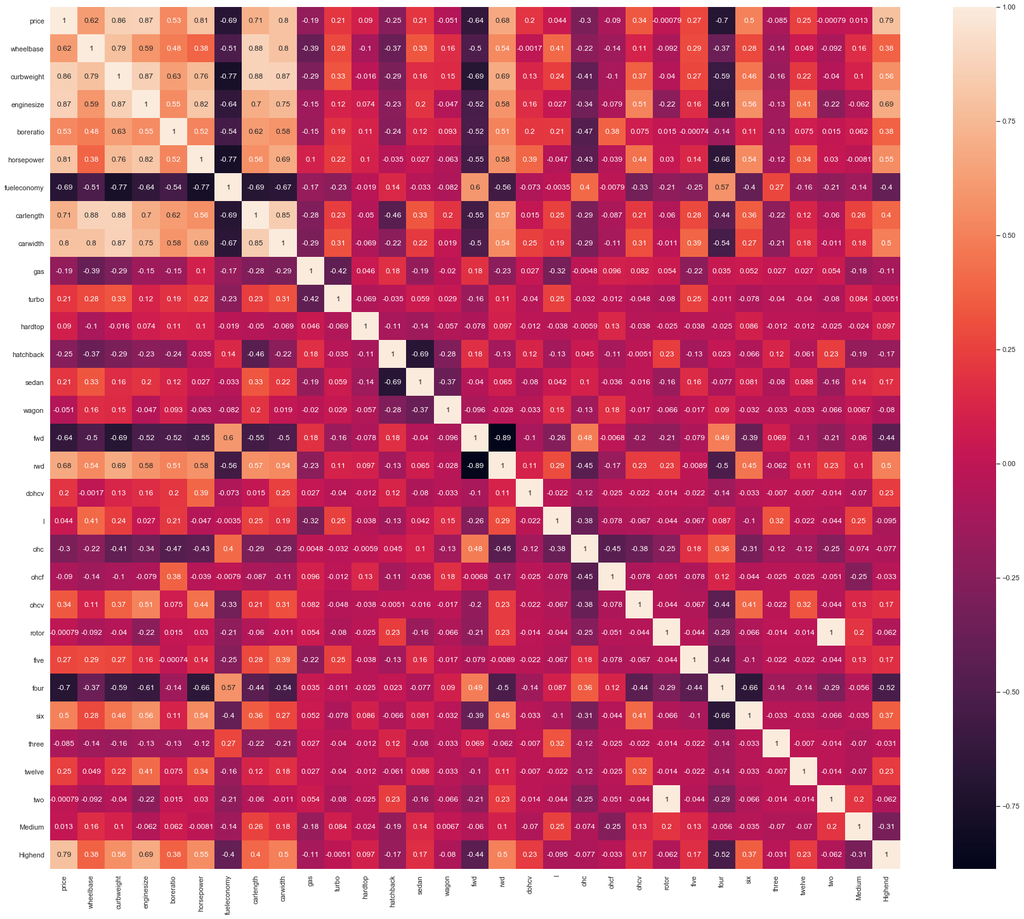

```python
#Correlation using heatmap
plt.figure(figsize = (30, 25))
sns.heatmap(df_train.corr(), annot = True)
plt.show()
```

- Highly correlated variables to price are - `curbweight`, `enginesize`, `horsepower`,`carwidth` and `highend`.

```python
#Dividing data into X and y variables
y_train = df_train.pop('price')
X_train = df_train
```

# Step 4: Data Modeling

- Finding the best fit Model
- Eliminating Variables that are interdependant and redundant
- Performing Residual Analysis on the Model
- Ending up with the best regression line with high Inference parameters

```python
#RFE
from sklearn.feature_selection import RFE
from sklearn.linear_model import LinearRegression
import statsmodels.api as sm
from statsmodels.stats.outliers_influence import variance_inflation_factor
```

```python
lm = LinearRegression()
lm.fit(X_train,y_train)
rfe = RFE(lm, 10)
rfe = rfe.fit(X_train, y_train)
```

```python
list(zip(X_train.columns,rfe.support_,rfe.ranking_))
```

```
[('wheelbase', False, 3),
 ('curbweight', True, 1),
 ('enginesize', False, 13),
 ('boreratio', False, 10),
 ('horsepower', True, 1),
 ('fueleconomy', True, 1),
 ('carlength', False, 11),
 ('carwidth', True, 1),
 ('gas', False, 17),
 ('turbo', False, 18),
 ('hardtop', False, 2),
 ('hatchback', True, 1),
 ('sedan', True, 1),
 ('wagon', True, 1),
 ('fwd', False, 16),
 ('rwd', False, 15),
 ('dohcv', True, 1),
 ('l', False, 19),
 ('ohc', False, 7),
 ('ohcf', False, 8),
 ('ohcv', False, 9),
 ('rotor', False, 20),
 ('five', False, 6),
 ('four', False, 4),
 ('six', False, 5),
 ('three', False, 14),
 ('twelve', True, 1),
 ('two', False, 21),
 ('Medium', False, 12),
 ('Highend', True, 1)]
```

```python
X_train.columns[rfe.support_]
```

```
Index(['curbweight', 'horsepower', 'fueleconomy', 'carwidth', 'hatchback',
       'sedan', 'wagon', 'dohcv', 'twelve', 'Highend'],
      dtype='object')
```

```python
X_train_rfe = X_train[X_train.columns[rfe.support_]]
X_train_rfe.head()
```

|  | curbweight | horsepower | fueleconomy | carwidth | hatchback | sedan | wagon | dohcv | twelve | Highend |
| --- | --- | --- | --- | --- | --- | --- | --- | --- | --- | --- |
| 122 | 0.2727 | 0.0833 | 0.5309 | 0.2917 | 0 | 1 | 0 | 0 | 0 | 0 |
| 125 | 0.5004 | 0.3958 | 0.2140 | 0.6667 | 1 | 0 | 0 | 0 | 0 | 1 |
| 166 | 0.3150 | 0.2667 | 0.3443 | 0.3083 | 1 | 0 | 0 | 0 | 0 | 0 |
| 1 | 0.4112 | 0.2625 | 0.2442 | 0.3167 | 0 | 0 | 0 | 0 | 0 | 0 |
| 199 | 0.6474 | 0.4750 | 0.1221 | 0.5750 | 0 | 0 | 1 | 0 | 0 | 0 |

```python
def build_model(X,y):
    X = sm.add_constant(X) #Adding the constant
    lm = sm.OLS(y,X).fit() # fitting the model
    print(lm.summary()) # model summary
    return X

def checkVIF(X):
    vif = pd.DataFrame()
    vif['Features'] = X.columns
    vif['VIF'] = [variance_inflation_factor(X.values, i) for i in range(X.shape[1])]
    vif['VIF'] = round(vif['VIF'], 2)
    vif = vif.sort_values(by = "VIF", ascending = False)
    return(vif)
```

## Model 1

```python
X_train_new = build_model(X_train_rfe,y_train)
```

```
                            OLS Regression Results
==============================================================================
Dep. Variable:                  price   R-squared:                       0.929
Model:                            OLS   Adj. R-squared:                  0.923
Method:                 Least Squares   F-statistic:                     172.1
Date:                Sat, 08 Aug 2020   Prob (F-statistic):           1.29e-70
Time:                        11:30:53   Log-Likelihood:                 205.85
No. Observations:                 143   AIC:                            -389.7
Df Residuals:                     132   BIC:                            -357.1
Df Model:                          10
Covariance Type:            nonrobust
===============================================================================
                  coef    std err          t      P>|t|      [0.025      0.975]
-------------------------------------------------------------------------------
const          -0.0947      0.042     -2.243      0.027      -0.178      -0.011
curbweight      0.2657      0.069      3.870      0.000       0.130       0.402
horsepower      0.4499      0.074      6.099      0.000       0.304       0.596
fueleconomy     0.0933      0.052      1.792      0.075      -0.010       0.196
carwidth        0.2609      0.062      4.216      0.000       0.138       0.383
hatchback      -0.0929      0.025     -3.707      0.000      -0.143      -0.043
sedan          -0.0704      0.025     -2.833      0.005      -0.120      -0.021
wagon          -0.0997      0.028     -3.565      0.001      -0.155      -0.044
dohcv          -0.2676      0.079     -3.391      0.001      -0.424      -0.112
twelve         -0.1192      0.067     -1.769      0.079      -0.253       0.014
Highend         0.2586      0.020     12.929      0.000       0.219       0.298
==============================================================================
Omnibus:                       43.093   Durbin-Watson:                   1.867
Prob(Omnibus):                  0.000   Jarque-Bera (JB):              130.648
Skew:                           1.128   Prob(JB):                     4.27e-29
Kurtosis:                       7.103   Cond. No.                         32.0
==============================================================================

Warnings:
[1] Standard Errors assume that the covariance matrix of the errors is correctly specified.
```

### p-value of `twelve` seems to be higher than the significance value of 0.05, hence dropping it as it is insignificant in presence of other variables.

```python
X_train_new = X_train_rfe.drop(["twelve"], axis = 1)
```

## Model 2

```python
X_train_new = build_model(X_train_new,y_train)
```

```
                            OLS Regression Results
==============================================================================
Dep. Variable:                  price   R-squared:                       0.927
Model:                            OLS   Adj. R-squared:                  0.922
Method:                 Least Squares   F-statistic:                     187.9
Date:                Sat, 08 Aug 2020   Prob (F-statistic):           4.25e-71
Time:                        11:30:53   Log-Likelihood:                 204.17
No. Observations:                 143   AIC:                            -388.3
Df Residuals:                     133   BIC:                            -358.7
Df Model:                           9
Covariance Type:            nonrobust
===============================================================================
                  coef    std err          t      P>|t|      [0.025      0.975]
-------------------------------------------------------------------------------
const          -0.0764      0.041     -1.851      0.066      -0.158       0.005
curbweight      0.2756      0.069      3.995      0.000       0.139       0.412
horsepower      0.3997      0.069      5.824      0.000       0.264       0.535
fueleconomy     0.0736      0.051      1.435      0.154      -0.028       0.175
carwidth        0.2580      0.062      4.137      0.000       0.135       0.381
hatchback      -0.0951      0.025     -3.766      0.000      -0.145      -0.045
sedan          -0.0744      0.025     -2.983      0.003      -0.124      -0.025
wagon          -0.1050      0.028     -3.744      0.000      -0.160      -0.050
dohcv          -0.2319      0.077     -3.015      0.003      -0.384      -0.080
Highend         0.2565      0.020     12.743      0.000       0.217       0.296
==============================================================================
Omnibus:                       48.027   Durbin-Watson:                   1.880
Prob(Omnibus):                  0.000   Jarque-Bera (JB):              159.802
Skew:                           1.231   Prob(JB):                     1.99e-35
Kurtosis:                       7.556   Cond. No.                         29.6
==============================================================================

Warnings:
[1] Standard Errors assume that the covariance matrix of the errors is correctly specified.
```

### p-value of `fueleconomy` seems to be higher than the significance value of 0.05, hence dropping it as it is insignificant in presence of other variables.

```python
X_train_new = X_train_rfe.drop(["twelve","fueleconomy"], axis = 1)
```

## Model 3

```python
X_train_new = build_model(X_train_new,y_train)
```

```
                            OLS Regression Results
==============================================================================
Dep. Variable:                  price   R-squared:                       0.926
Model:                            OLS   Adj. R-squared:                  0.922
Method:                 Least Squares   F-statistic:                     209.5
Date:                Sat, 08 Aug 2020   Prob (F-statistic):           7.85e-72
Time:                        11:30:53   Log-Likelihood:                 203.07
No. Observations:                 143   AIC:                            -388.1
Df Residuals:                     134   BIC:                            -361.5
Df Model:                           8
Covariance Type:            nonrobust
==============================================================================
                 coef    std err          t      P>|t|      [0.025      0.975]
------------------------------------------------------------------------------
const         -0.0305      0.026     -1.165      0.246      -0.082       0.021
curbweight     0.2593      0.068      3.796      0.000       0.124       0.394
horsepower     0.3469      0.058      5.964      0.000       0.232       0.462
carwidth       0.2488      0.062      3.995      0.000       0.126       0.372
hatchback     -0.0922      0.025     -3.650      0.000      -0.142      -0.042
sedan         -0.0711      0.025     -2.850      0.005      -0.120      -0.022
wagon         -0.1047      0.028     -3.721      0.000      -0.160      -0.049
dohcv         -0.1968      0.073     -2.689      0.008      -0.342      -0.052
Highend        0.2610      0.020     13.083      0.000       0.222       0.301
==============================================================================
Omnibus:                       48.637   Durbin-Watson:                   1.909
Prob(Omnibus):                  0.000   Jarque-Bera (JB):              161.444
Skew:                           1.250   Prob(JB):                     8.77e-36
Kurtosis:                       7.566   Cond. No.                         27.2
==============================================================================

Warnings:
[1] Standard Errors assume that the covariance matrix of the errors is correctly specified.
```

```python
#Calculating the Variance Inflation Factor
checkVIF(X_train_new)
```

|  | Features | VIF |
| --- | --- | --- |
| 0 | const | 26.9000 |
| 1 | curbweight | 8.1000 |
| 5 | sedan | 6.0700 |
| 4 | hatchback | 5.6300 |
| 3 | carwidth | 5.1400 |
| 2 | horsepower | 3.6100 |
| 6 | wagon | 3.5800 |
| 8 | Highend | 1.6300 |
| 7 | dohcv | 1.4600 |

### VIF of `curbweight` seems to be greater than 5. So let's remove it as it will cause multicollinearity issue

```python
X_train_new = X_train_rfe.drop(["twelve","fueleconomy","curbweight"], axis = 1)
```

## Model 4

```python
X_train_new = build_model(X_train_new,y_train)
```

```
                            OLS Regression Results
==============================================================================
Dep. Variable:                  price   R-squared:                       0.918
Model:                            OLS   Adj. R-squared:                  0.914
Method:                 Least Squares   F-statistic:                     215.9
Date:                Sat, 08 Aug 2020   Prob (F-statistic):           4.70e-70
Time:                        11:30:53   Log-Likelihood:                 195.77
No. Observations:                 143   AIC:                            -375.5
Df Residuals:                     135   BIC:                            -351.8
Df Model:                           7
Covariance Type:            nonrobust
==============================================================================
                 coef    std err          t      P>|t|      [0.025      0.975]
------------------------------------------------------------------------------
const         -0.0319      0.027     -1.161      0.248      -0.086       0.022
horsepower     0.4690      0.051      9.228      0.000       0.368       0.569
carwidth       0.4269      0.043      9.944      0.000       0.342       0.512
hatchback     -0.1044      0.026     -3.976      0.000      -0.156      -0.052
sedan         -0.0756      0.026     -2.896      0.004      -0.127      -0.024
wagon         -0.0865      0.029     -2.974      0.003      -0.144      -0.029
dohcv         -0.3106      0.070     -4.435      0.000      -0.449      -0.172
Highend        0.2772      0.020     13.559      0.000       0.237       0.318
==============================================================================
Omnibus:                       43.937   Durbin-Watson:                   2.006
Prob(Omnibus):                  0.000   Jarque-Bera (JB):              127.746
Skew:                           1.171   Prob(JB):                     1.82e-28
Kurtosis:                       6.995   Cond. No.                         18.0
==============================================================================

Warnings:
[1] Standard Errors assume that the covariance matrix of the errors is correctly specified.
```

```python
#Calculating the Variance Inflation Factor
checkVIF(X_train_new)
```

|  | Features | VIF |
| --- | --- | --- |
| 0 | const | 26.8900 |
| 4 | sedan | 6.0600 |
| 3 | hatchback | 5.5400 |
| 5 | wagon | 3.4700 |
| 1 | horsepower | 2.5000 |
| 2 | carwidth | 2.2200 |
| 7 | Highend | 1.5600 |
| 6 | dohcv | 1.2100 |

### VIF of `sedan` seems to be greater than 5. So let's remove it as it will cause multicollinearity issue

```python
X_train_new = X_train_rfe.drop(["twelve","fueleconomy","sedan","curbweight"], axis = 1)
```

## Model 5

```python
X_train_new = build_model(X_train_new,y_train)
```

```
                            OLS Regression Results
==============================================================================
Dep. Variable:                  price   R-squared:                       0.913
Model:                            OLS   Adj. R-squared:                  0.909
Method:                 Least Squares   F-statistic:                     237.6
Date:                Sat, 08 Aug 2020   Prob (F-statistic):           1.68e-69
Time:                        11:30:53   Log-Likelihood:                 191.46
No. Observations:                 143   AIC:                            -368.9
Df Residuals:                     136   BIC:                            -348.2
Df Model:                           6
Covariance Type:            nonrobust
==============================================================================
                 coef    std err          t      P>|t|      [0.025      0.975]
------------------------------------------------------------------------------
const         -0.0934      0.018     -5.219      0.000      -0.129      -0.058
horsepower     0.5001      0.051      9.805      0.000       0.399       0.601
carwidth       0.3963      0.043      9.275      0.000       0.312       0.481
hatchback     -0.0373      0.013     -2.938      0.004      -0.062      -0.012
wagon         -0.0170      0.017     -1.008      0.315      -0.050       0.016
dohcv         -0.3203      0.072     -4.460      0.000      -0.462      -0.178
Highend        0.2808      0.021     13.402      0.000       0.239       0.322
==============================================================================
Omnibus:                       34.143   Durbin-Watson:                   2.024
Prob(Omnibus):                  0.000   Jarque-Bera (JB):               72.788
Skew:                           1.018   Prob(JB):                     1.56e-16
Kurtosis:                       5.841   Cond. No.                         16.4
==============================================================================

Warnings:
[1] Standard Errors assume that the covariance matrix of the errors is correctly specified.
```

### P-Value of `wagon` increased more than 0.05 deeming it as insignificant

```python
X_train_new = X_train_rfe.drop(["twelve","fueleconomy","sedan","curbweight","wagon"], axis = 1)
```

## Model 6

```python
X_train_new = build_model(X_train_new,y_train)
```

```
                            OLS Regression Results
==============================================================================
Dep. Variable:                  price   R-squared:                       0.912
Model:                            OLS   Adj. R-squared:                  0.909
Method:                 Least Squares   F-statistic:                     284.8
Date:                Sat, 08 Aug 2020   Prob (F-statistic):           1.57e-70
Time:                        11:30:53   Log-Likelihood:                 190.93
No. Observations:                 143   AIC:                            -369.9
Df Residuals:                     137   BIC:                            -352.1
Df Model:                           5
Covariance Type:            nonrobust
==============================================================================
                 coef    std err          t      P>|t|      [0.025      0.975]
------------------------------------------------------------------------------
const         -0.0970      0.018     -5.530      0.000      -0.132      -0.062
horsepower     0.5013      0.051      9.832      0.000       0.401       0.602
carwidth       0.3952      0.043      9.252      0.000       0.311       0.480
hatchback     -0.0336      0.012     -2.764      0.006      -0.058      -0.010
dohcv         -0.3231      0.072     -4.502      0.000      -0.465      -0.181
Highend        0.2833      0.021     13.615      0.000       0.242       0.324
==============================================================================
Omnibus:                       36.097   Durbin-Watson:                   2.028
Prob(Omnibus):                  0.000   Jarque-Bera (JB):               78.717
Skew:                           1.067   Prob(JB):                     8.07e-18
Kurtosis:                       5.943   Cond. No.                         16.3
==============================================================================

Warnings:
[1] Standard Errors assume that the covariance matrix of the errors is correctly specified.
```

```python
#Calculating the Variance Inflation Factor
checkVIF(X_train_new)
```

|  | Features | VIF |
| --- | --- | --- |
| 0 | const | 10.3900 |
| 1 | horsepower | 2.3900 |
| 2 | carwidth | 2.0800 |
| 5 | Highend | 1.5300 |
| 4 | dohcv | 1.2100 |
| 3 | hatchback | 1.1300 |

### Model seems to be pretty good. Still lets drop some columns and see if we can maintain that same accuracy

```python
X_train_new = X_train_rfe.drop(["twelve","fueleconomy","sedan","curbweight","wagon","dohcv"], axis = 1)
```

## Model 7

```python
X_train_new = build_model(X_train_new,y_train)
#Calculating the Variance Inflation Factor
checkVIF(X_train_new)
```

```
                            OLS Regression Results
==============================================================================
Dep. Variable:                  price   R-squared:                       0.899
Model:                            OLS   Adj. R-squared:                  0.896
Method:                 Least Squares   F-statistic:                     308.0
Date:                Sat, 08 Aug 2020   Prob (F-statistic):           1.04e-67
Time:                        11:30:54   Log-Likelihood:                 181.06
No. Observations:                 143   AIC:                            -352.1
Df Residuals:                     138   BIC:                            -337.3
Df Model:                           4
Covariance Type:            nonrobust
==============================================================================
                 coef    std err          t      P>|t|      [0.025      0.975]
------------------------------------------------------------------------------
const         -0.0824      0.018     -4.480      0.000      -0.119      -0.046
horsepower     0.4402      0.052      8.390      0.000       0.336       0.544
carwidth       0.3957      0.046      8.677      0.000       0.306       0.486
hatchback     -0.0414      0.013     -3.219      0.002      -0.067      -0.016
Highend        0.2794      0.022     12.591      0.000       0.236       0.323
==============================================================================
Omnibus:                       29.385   Durbin-Watson:                   1.955
Prob(Omnibus):                  0.000   Jarque-Bera (JB):               98.010
Skew:                           0.692   Prob(JB):                     5.22e-22
Kurtosis:                       6.812   Cond. No.                         12.9
==============================================================================

Warnings:
[1] Standard Errors assume that the covariance matrix of the errors is correctly specified.
```

|  | Features | VIF |
| --- | --- | --- |
| 0 | const | 10.0400 |
| 1 | horsepower | 2.2200 |
| 2 | carwidth | 2.0800 |
| 4 | Highend | 1.5300 |
| 3 | hatchback | 1.1000 |

### We can see R square reduced by 1 percent but it is still a very good model considering the drop of one Column

```python
# Lets Drop one more column and see the accuracy
X_train_new = X_train_rfe.drop(["twelve","fueleconomy","sedan","curbweight","wagon","dohcv","horsepower"], axis = 1)
```

## Model 8

```python
X_train_new = build_model(X_train_new,y_train)
#Calculating the Variance Inflation Factor
checkVIF(X_train_new)
```

```
                            OLS Regression Results
==============================================================================
Dep. Variable:                  price   R-squared:                       0.848
Model:                            OLS   Adj. R-squared:                  0.845
Method:                 Least Squares   F-statistic:                     258.3
Date:                Sat, 08 Aug 2020   Prob (F-statistic):           1.26e-56
Time:                        11:30:54   Log-Likelihood:                 151.59
No. Observations:                 143   AIC:                            -295.2
Df Residuals:                     139   BIC:                            -283.3
Df Model:                           3
Covariance Type:            nonrobust
==============================================================================
                 coef    std err          t      P>|t|      [0.025      0.975]
------------------------------------------------------------------------------
const         -0.1018      0.022     -4.553      0.000      -0.146      -0.058
carwidth       0.6208      0.045     13.752      0.000       0.532       0.710
hatchback     -0.0194      0.015     -1.257      0.211      -0.050       0.011
Highend        0.3459      0.025     13.627      0.000       0.296       0.396
==============================================================================
Omnibus:                       33.649   Durbin-Watson:                   2.001
Prob(Omnibus):                  0.000   Jarque-Bera (JB):               68.062
Skew:                           1.027   Prob(JB):                     1.66e-15
Kurtosis:                       5.684   Cond. No.                         8.45
==============================================================================

Warnings:
[1] Standard Errors assume that the covariance matrix of the errors is correctly specified.
```

|  | Features | VIF |
| --- | --- | --- |
| 0 | const | 9.8800 |
| 1 | carwidth | 1.3600 |
| 3 | Highend | 1.3300 |
| 2 | hatchback | 1.0600 |

#### Model R Square dropped by 5 percent. Which is not good even though it is a pretty good model with R-square as 84%. Lets us Keep `Horsepower` and drop other columns and check

```python
# Lets Drop some other column and see the accuracy
X_train_new = X_train_rfe.drop(["twelve","fueleconomy","sedan","curbweight","wagon","dohcv","hatchback"], axis = 1)
```

## Model 9

```python
X_train_new = build_model(X_train_new,y_train)
#Calculating the Variance Inflation Factor
checkVIF(X_train_new)
```

```
                            OLS Regression Results
==============================================================================
Dep. Variable:                  price   R-squared:                       0.892
Model:                            OLS   Adj. R-squared:                  0.889
Method:                 Least Squares   F-statistic:                     381.5
Date:                Sat, 08 Aug 2020   Prob (F-statistic):           7.18e-67
Time:                        11:30:54   Log-Likelihood:                 175.89
No. Observations:                 143   AIC:                            -343.8
Df Residuals:                     139   BIC:                            -331.9
Df Model:                           3
Covariance Type:            nonrobust
==============================================================================
                 coef    std err          t      P>|t|      [0.025      0.975]
------------------------------------------------------------------------------
const         -0.1068      0.017     -6.159      0.000      -0.141      -0.072
horsepower     0.4057      0.053      7.646      0.000       0.301       0.511
carwidth       0.4320      0.046      9.465      0.000       0.342       0.522
Highend        0.2895      0.023     12.754      0.000       0.245       0.334
==============================================================================
Omnibus:                       32.602   Durbin-Watson:                   1.968
Prob(Omnibus):                  0.000   Jarque-Bera (JB):              130.498
Skew:                           0.714   Prob(JB):                     4.60e-29
Kurtosis:                       7.456   Cond. No.                         11.9
==============================================================================

Warnings:
[1] Standard Errors assume that the covariance matrix of the errors is correctly specified.
```

|  | Features | VIF |
| --- | --- | --- |
| 0 | const | 8.3500 |
| 1 | horsepower | 2.1300 |
| 2 | carwidth | 1.9600 |
| 3 | Highend | 1.5000 |

### Dropping `Hatchback` did not effect the R square much. So Let us keep it that way for building a Simplistic Model

```python
# Lets Drop some other column and see the accuracy
X_train_new = X_train_rfe.drop(["twelve","fueleconomy","sedan","curbweight","wagon","dohcv","hatchback","carwidth"], axis = 1)
```

## Model 10

```python
X_train_new = build_model(X_train_new,y_train)
#Calculating the Variance Inflation Factor
checkVIF(X_train_new)
```

```
                            OLS Regression Results
==============================================================================
Dep. Variable:                  price   R-squared:                       0.822
Model:                            OLS   Adj. R-squared:                  0.819
Method:                 Least Squares   F-statistic:                     323.1
Date:                Sat, 08 Aug 2020   Prob (F-statistic):           3.50e-53
Time:                        11:30:54   Log-Likelihood:                 140.32
No. Observations:                 143   AIC:                            -274.6
Df Residuals:                     140   BIC:                            -265.8
Df Model:                           2
Covariance Type:            nonrobust
==============================================================================
                 coef    std err          t      P>|t|      [0.025      0.975]
------------------------------------------------------------------------------
const          0.0230      0.014      1.697      0.092      -0.004       0.050
horsepower     0.6906      0.056     12.366      0.000       0.580       0.801
Highend        0.3309      0.028     11.628      0.000       0.275       0.387
==============================================================================
Omnibus:                       24.500   Durbin-Watson:                   2.109
Prob(Omnibus):                  0.000   Jarque-Bera (JB):               41.068
Skew:                           0.827   Prob(JB):                     1.21e-09
Kurtosis:                       5.038   Cond. No.                         8.01
==============================================================================

Warnings:
[1] Standard Errors assume that the covariance matrix of the errors is correctly specified.
```

|  | Features | VIF |
| --- | --- | --- |
| 0 | const | 3.1300 |
| 1 | horsepower | 1.4400 |
| 2 | Highend | 1.4400 |

### Dropping `Car width` reduced R Square of Model by 7 percent. So let us keep it

```python
# Lets Drop some other column and see the accuracy
X_train_new = X_train_rfe.drop(["twelve","fueleconomy","sedan","curbweight","wagon","dohcv","hatchback","Highend"], axis = 1)
```

## Model 11

```python
X_train_new = build_model(X_train_new,y_train)
#Calculating the Variance Inflation Factor
checkVIF(X_train_new)
```

```
                            OLS Regression Results
==============================================================================
Dep. Variable:                  price   R-squared:                       0.765
Model:                            OLS   Adj. R-squared:                  0.762
Method:                 Least Squares   F-statistic:                     227.9
Date:                Sat, 08 Aug 2020   Prob (F-statistic):           9.48e-45
Time:                        11:30:54   Log-Likelihood:                 120.49
No. Observations:                 143   AIC:                            -235.0
Df Residuals:                     140   BIC:                            -226.1
Df Model:                           2
Covariance Type:            nonrobust
==============================================================================
                 coef    std err          t      P>|t|      [0.025      0.975]
------------------------------------------------------------------------------
const         -0.1763      0.024     -7.297      0.000      -0.224      -0.129
horsepower     0.6349      0.073      8.663      0.000       0.490       0.780
carwidth       0.5443      0.066      8.279      0.000       0.414       0.674
==============================================================================
Omnibus:                       43.125   Durbin-Watson:                   1.751
Prob(Omnibus):                  0.000   Jarque-Bera (JB):               97.520
Skew:                           1.266   Prob(JB):                     6.67e-22
Kurtosis:                       6.156   Cond. No.                         11.7
==============================================================================

Warnings:
[1] Standard Errors assume that the covariance matrix of the errors is correctly specified.
```

|  | Features | VIF |
| --- | --- | --- |
| 0 | const | 7.5200 |
| 1 | horsepower | 1.8800 |
| 2 | carwidth | 1.8800 |

### Dropping `Highend` reduced R Square of Model by 12 percent. So let us keep it

## Final Model - Model 9

```python
# Lets Drop some other column and see the accuracy
X_train_new = X_train_rfe.drop(["twelve","fueleconomy","sedan","curbweight","wagon","dohcv","hatchback"], axis = 1)

X_train_new = build_model(X_train_new,y_train)
#Calculating the Variance Inflation Factor
checkVIF(X_train_new)
```

```
                            OLS Regression Results
==============================================================================
Dep. Variable:                  price   R-squared:                       0.892
Model:                            OLS   Adj. R-squared:                  0.889
Method:                 Least Squares   F-statistic:                     381.5
Date:                Sat, 08 Aug 2020   Prob (F-statistic):           7.18e-67
Time:                        11:30:54   Log-Likelihood:                 175.89
No. Observations:                 143   AIC:                            -343.8
Df Residuals:                     139   BIC:                            -331.9
Df Model:                           3
Covariance Type:            nonrobust
==============================================================================
                 coef    std err          t      P>|t|      [0.025      0.975]
------------------------------------------------------------------------------
const         -0.1068      0.017     -6.159      0.000      -0.141      -0.072
horsepower     0.4057      0.053      7.646      0.000       0.301       0.511
carwidth       0.4320      0.046      9.465      0.000       0.342       0.522
Highend        0.2895      0.023     12.754      0.000       0.245       0.334
==============================================================================
Omnibus:                       32.602   Durbin-Watson:                   1.968
Prob(Omnibus):                  0.000   Jarque-Bera (JB):              130.498
Skew:                           0.714   Prob(JB):                     4.60e-29
Kurtosis:                       7.456   Cond. No.                         11.9
==============================================================================

Warnings:
[1] Standard Errors assume that the covariance matrix of the errors is correctly specified.
```

|  | Features | VIF |
| --- | --- | --- |
| 0 | const | 8.3500 |
| 1 | horsepower | 2.1300 |
| 2 | carwidth | 1.9600 |
| 3 | Highend | 1.5000 |

## Residual Analysis of the Model

```python
lm = sm.OLS(y_train,X_train_new).fit()
y_train_price = lm.predict(X_train_new)
```

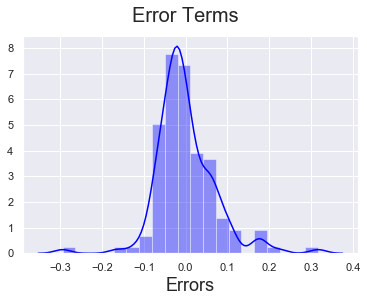

```python
# Plot the histogram of the error terms
fig = plt.figure()
sns.distplot((y_train - y_train_price), bins = 20)
fig.suptitle('Error Terms', fontsize = 20)                  # Plot heading
plt.xlabel('Errors', fontsize = 18)
```

- Error terms seem to be approximately normally distributed, so the assumption on the linear modeling seems to be fulfilled.

# Step 5: Model Prediction and Evalutaion

```python
#Scaling the test set
num_vars = ['wheelbase', 'curbweight', 'enginesize', 'boreratio', 'horsepower','fueleconomy','carlength','carwidth','price']
df_test[num_vars] = scaler.fit_transform(df_test[num_vars])
```

```python
#Dividing into X and y
y_test = df_test.pop('price')
X_test = df_test
```

```python
# Now let's use our model to make predictions.
X_train_new = X_train_new.drop('const',axis=1)
# Creating X_test_new dataframe by dropping variables from X_test
X_test_new = X_test[X_train_new.columns]

# Adding a constant variable
X_test_new = sm.add_constant(X_test_new)
```

```python
# Making predictions
y_pred = lm.predict(X_test_new)
```

### Evaluation of test via comparison of y_pred and y_test

```python
from sklearn.metrics import r2_score
r2_score(y_test, y_pred)
```

```
0.8738336814654235
```

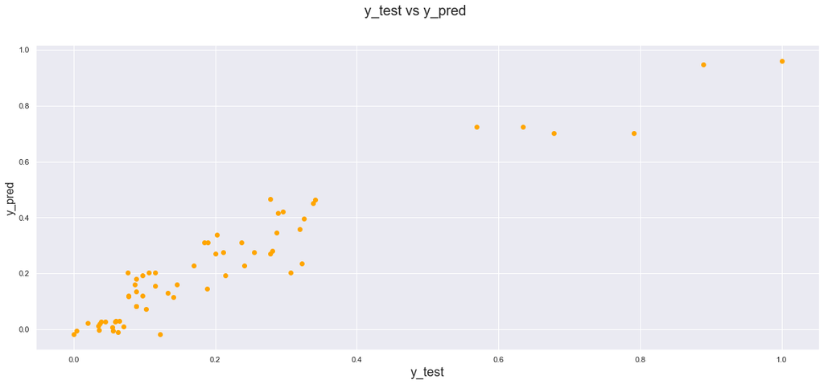

```python
#EVALUATION OF THE MODEL
# Plotting y_test and y_pred to understand the spread.
fig = plt.figure(figsize=(20,8))
plt.scatter(y_test,y_pred,color='orange')
fig.suptitle('y_test vs y_pred', fontsize=20)              # Plot heading
plt.xlabel('y_test', fontsize=18)                          # X-label
plt.ylabel('y_pred', fontsize=16)
plt.show()
```

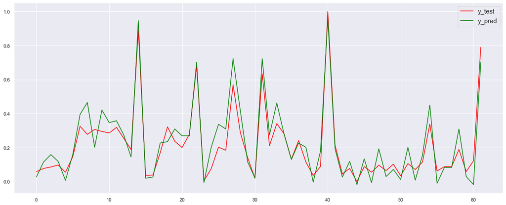

```python
d = {'y_pred':y_pred, 'y_test':y_test}
df = pd.DataFrame(data=d).reset_index()
df = df.drop(['index'],axis=1)
plt.figure(figsize=(20,8))
plt.plot(df['y_test'].index, df['y_test'], color = "red")
plt.plot(df['y_pred'].index, df['y_pred'], color = "green")
plt.legend(['y_test','y_pred'], fontsize='large')
plt.show()
```

# Step 6 : Conclusion

```python
print(lm.summary())
```

```
                            OLS Regression Results
==============================================================================
Dep. Variable:                  price   R-squared:                       0.892
Model:                            OLS   Adj. R-squared:                  0.889
Method:                 Least Squares   F-statistic:                     381.5
Date:                Sat, 08 Aug 2020   Prob (F-statistic):           7.18e-67
Time:                        11:30:55   Log-Likelihood:                 175.89
No. Observations:                 143   AIC:                            -343.8
Df Residuals:                     139   BIC:                            -331.9
Df Model:                           3
Covariance Type:            nonrobust
==============================================================================
                 coef    std err          t      P>|t|      [0.025      0.975]
------------------------------------------------------------------------------
const         -0.1068      0.017     -6.159      0.000      -0.141      -0.072
horsepower     0.4057      0.053      7.646      0.000       0.301       0.511
carwidth       0.4320      0.046      9.465      0.000       0.342       0.522
Highend        0.2895      0.023     12.754      0.000       0.245       0.334
==============================================================================
Omnibus:                       32.602   Durbin-Watson:                   1.968
Prob(Omnibus):                  0.000   Jarque-Bera (JB):              130.498
Skew:                           0.714   Prob(JB):                     4.60e-29
Kurtosis:                       7.456   Cond. No.                         11.9
==============================================================================

Warnings:
[1] Standard Errors assume that the covariance matrix of the errors is correctly specified.
```

### Final Analysis

1. *R-sqaured and Adjusted R-squared (extent of fit)* - 0.892 and 0.889 - `90%` variance explained.
2. *F-stats and Prob(F-stats) (overall model fit)* - 381.5 and 7.18e-67(approx. 0.0) - Model fir is significant and explained `90%` variance is just not by chance.
3. *p-values* - p-values for all the coefficients seem to be less than the significance level of 0.05. - meaning that all the predictors are statistically significant.

### We can see that the equation of our best fitted line is:

**price = 0.4057 horsepower + 0.4320 carwidth + 0.2895 Highend - 0.1068**